# Lab_7 Heart Attack

Author

Mehrpad Moattari

Published

November 28, 2023

```python
import pandas as pd
from sklearn.pipeline import Pipeline
from sklearn.neighbors import KNeighborsClassifier
from sklearn.tree import DecisionTreeClassifier
from sklearn.linear_model import LogisticRegression
```

```python
df=pd.read_csv("C:/Users/mehrp/OneDrive/Documents/GitHub/Lab_7/heart_attack.csv")
df.head()
```

|  | age | sex | cp | trtbps | chol | restecg | thalach | output |
| --- | --- | --- | --- | --- | --- | --- | --- | --- |
| 0 | 63 | 1 | 3 | 145 | 233 | 0 | 150 | 1 |
| 1 | 37 | 1 | 2 | 130 | 250 | 1 | 187 | 1 |
| 2 | 56 | 1 | 1 | 120 | 236 | 1 | 178 | 1 |
| 3 | 57 | 0 | 0 | 120 | 354 | 1 | 163 | 1 |
| 4 | 57 | 1 | 0 | 140 | 192 | 1 | 148 | 1 |

## Part One: Fitting Models

### KNN Classification

```python
from sklearn.preprocessing import StandardScaler
from sklearn.model_selection import cross_val_score
from sklearn.metrics import confusion_matrix, roc_curve, auc
import matplotlib.pyplot as plt
from sklearn.model_selection import train_test_split

# Splitting up the data - 'X' for the stuff we know, 'y' for what we're guessing.
X=df.drop("output", axis=1)
y=df["output"]

# Let's try out different numbers of neighbors in our KNN.
ns=[1,10,100,200]
knc_auc_list=[]

# Time for a loop - let's see which number of neighbors is the golden ticket
for n in ns:

    # Making a pipeline: first, make all our data play nice (standardize it), then hit it with the KNN.
    knc_pipeline=Pipeline(
        [
            ("standardize", StandardScaler()),
            ("knc", KNeighborsClassifier(n_neighbors=n))
        ]
    )


    knc_auc=cross_val_score(knc_pipeline, X, y, cv=5, scoring='roc_auc').mean()
    knc_auc_list.append(knc_auc)

# Let's see our AUC scores in a neat little table
knc_auc_df=pd.DataFrame({'n': ns, 'AUC': knc_auc_list})

knc_auc_df
```

|  | n | AUC |
| --- | --- | --- |
| 0 | 1 | 0.698668 |
| 1 | 10 | 0.810824 |
| 2 | 100 | 0.837824 |
| 3 | 200 | 0.824572 |

Based on the output, it seems like 100 neighbors give the highest AUC score. This means that a KNN model with 100 neighbors is, on average, best at distinguishing between patients at risk of a heart attack and those not at risk, according to the data.

```
Confusion Matrix:
 [[29  7]
 [21 25]]
```

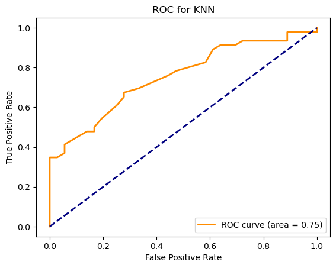

```python
# Splitting data for training and testing.
X_train, X_test, y_train, y_test = train_test_split(X, y, test_size=0.3, random_state=42)

# KNN with 100 neighbors - our best pick.
knc_pipeline_fitted = Pipeline(
    [
        ("standardize", StandardScaler()),
        ("knc", KNeighborsClassifier(n_neighbors=100))
    ]
)
knc_pipeline_fitted.fit(X_train, y_train)  # Train it!

# Making predictions and getting confusion matrix.
y_knc_test_pred = knc_pipeline_fitted.predict(X_test)
conf_matrix_knc = confusion_matrix(y_test, y_knc_test_pred)

# Calculating ROC curve and AUC.
y_knc_test_prob = knc_pipeline_fitted.predict_proba(X_test)
fpr_knc, tpr_knc, _ = roc_curve(y_test, y_knc_test_prob[:,1])
roc_auc_knc = auc(fpr_knc, tpr_knc)

print("Confusion Matrix:/n", conf_matrix_knc)

# Plotting the ROC curve.
plt.figure()
plt.plot(fpr_knc, tpr_knc, color='darkorange', lw=2, label=f'ROC curve (area = {roc_auc_knc:.2f})')
plt.plot([0, 1], [0, 1], color='navy', lw=2, linestyle='--')
plt.xlabel('False Positive Rate')
plt.ylabel('True Positive Rate')
plt.title('ROC for KNN')
plt.legend(loc="lower right")
plt.show()
```

The ROC curve for the KNN classifier shows a decent balance between the true positive rate (sensitivity) and false positive rate, with an AUC of 0.75. This means the model has a 75% chance of correctly distinguishing between the classes.

### Logistic Regression

```
The cross-validated ROC-AUC is 0.85
Confusion Matrix:
 [[26 10]
 [18 28]]
```

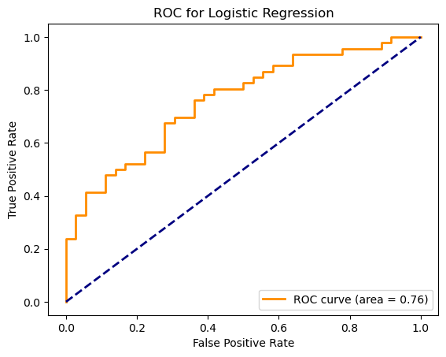

```python
# Logistic regression time - setting up the pipeline.
logreg_pipeline = Pipeline(
    [
        ("standardize", StandardScaler()),  # Gotta normalize the features first.
        ("logreg", LogisticRegression())    # The logistic regression model.
    ]
)

# Check how well our model does using AUC as the yardstick.
logreg_auc = cross_val_score(logreg_pipeline, X, y, cv=5, scoring='roc_auc')
print(f"The cross-validated ROC-AUC is {logreg_auc.mean():.2f}")

# Train the model on the training data.
logreg_pipeline.fit(X_train, y_train)

# Make predictions and see where they land.
y_logreg_test_pred = logreg_pipeline.predict(X_test)
conf_matrix_logreg = confusion_matrix(y_test, y_logreg_test_pred)

# Get the probs to plot an ROC curve.
y_logreg_test_prob = logreg_pipeline.predict_proba(X_test)
fpr_logreg, tpr_logreg, _ = roc_curve(y_test, y_logreg_test_prob[:,1])
roc_auc_logreg = auc(fpr_logreg, tpr_logreg)

print("Confusion Matrix:/n", conf_matrix_logreg)

# Let's get visual - plotting the ROC curve.
plt.figure()
plt.plot(fpr_logreg, tpr_logreg, color='darkorange', lw=2, label=f'ROC curve (area = {roc_auc_logreg:.2f})')
plt.plot([0, 1], [0, 1], color='navy', lw=2, linestyle='--')
plt.xlabel('False Positive Rate')
plt.ylabel('True Positive Rate')
plt.title('ROC for Logistic Regression')
plt.legend(loc="lower right")
plt.show()
```

The ROC curve for the Logistic Regression model is showing a decent performance with an AUC of 0.76. This AUC value suggests that the model has a 76% chance of correctly differentiating between the positive and negative classes.

Notably, the cross-validated ROC-AUC score mentioned in the code is 0.85, which suggests that the model may perform slightly better on average across different subsets of the data than what we see in this particular test set.

### Decision Tree

```python
# Let's see how tweaking the min_samples_leaf parameter affects Decision Trees.
samples_leaves = [5, 10, 50, 100]
dtc_auc_list = []

# Looping through different sizes for the minimum samples per leaf.
for samples_leave in samples_leaves:
    # Building a pipeline for our decision tree, including data scaling.
    dtc_pipeline = Pipeline(
        [
            ("standardize", StandardScaler()),
            ("dtc", DecisionTreeClassifier(min_samples_leaf=samples_leave))
        ]
    )

    # Getting the average ROC-AUC score from cross-validation.
    dtc_auc = cross_val_score(dtc_pipeline, X, y, cv=5, scoring='roc_auc').mean()
    dtc_auc_list.append(dtc_auc)

# Wrapping up the scores in a DataFrame to compare.
dtc_auc_df = pd.DataFrame({'min_samples_leaf': samples_leaves, 'AUC': dtc_auc_list})
dtc_auc_df
```

|  | min_samples_leaf | AUC |
| --- | --- | --- |
| 0 | 5 | 0.772687 |
| 1 | 10 | 0.795048 |
| 2 | 50 | 0.791481 |
| 3 | 100 | 0.753333 |

```
Confusion Matrix:
 [[24 12]
 [16 30]]
```

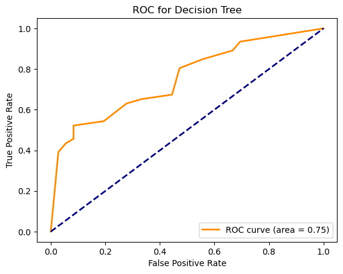

```python
# Decision Tree model with the best min_samples_leaf we found.
dtc_pipeline_fitted = Pipeline(
    [
        ("standardize", StandardScaler()),  # Standardization: a must-do before any model!
        ("dtc", DecisionTreeClassifier(min_samples_leaf=10))  # DT with our best leaf size.
    ]
)
dtc_pipeline_fitted.fit(X_train, y_train)  # Training the model with the training set.

# Let's see what the model predicts on our test set.
y_dtc_test_pred = dtc_pipeline_fitted.predict(X_test)
conf_matrix_dtc = confusion_matrix(y_test, y_dtc_test_pred)  # Checking how many we got right and wrong.

# Also get the probability scores needed to plot the ROC curve.
y_dtc_test_prob = dtc_pipeline_fitted.predict_proba(X_test)
fpr_dtc, tpr_dtc, _ = roc_curve(y_test, y_dtc_test_prob[:,1])
roc_auc_dtc = auc(fpr_dtc, tpr_dtc)  # The AUC score will tell us how good our model is overall.

print("Confusion Matrix:/n", conf_matrix_dtc)

# And now for some visuals - plotting the ROC curve.
plt.figure()
plt.plot(fpr_dtc, tpr_dtc, color='darkorange', lw=2, label=f'ROC curve (area = {roc_auc_dtc:.2f})')
plt.plot([0, 1], [0, 1], color='navy', lw=2, linestyle='--')  # That dashed line is our baseline.
plt.xlabel('False Positive Rate')
plt.ylabel('True Positive Rate')
plt.title('ROC for Decision Tree')
plt.legend(loc="lower right")
plt.show()  # Show the plot!
```

The ROC curve for the Decision Tree model shows an AUC of 0.75, indicating that the model has a 75% chance of correctly classifying a randomly chosen positive instance higher than a randomly chosen negative instance. The model performs well but isn’t perfect; there’s a steady climb towards the top-left corner but not quite close to the ideal curve.

### Interpretation

To determine the most important predictors in a dataset for tasks like predicting heart attack risk, one would look at the coefficients of a logistic regression model or the feature importances given by tree-based models such as Decision Trees or Random Forests.

# Part Two: Metrics

```python
from sklearn.metrics import make_scorer

# Part II, let's check how often our models get the positives right - that's the recall.
recall_knc = cross_val_score(knc_pipeline_fitted, X, y, cv=5, scoring='recall').mean()
recall_logreg = cross_val_score(logreg_pipeline, X, y, cv=5, scoring='recall').mean()
recall_dtc = cross_val_score(dtc_pipeline_fitted, X, y, cv=5, scoring='recall').mean()

# Now, let's look at precision - when our models say 'yes', how often is it a 'true yes'?
precision_knc = cross_val_score(knc_pipeline_fitted, X, y, cv=5, scoring='precision').mean()
precision_logreg = cross_val_score(logreg_pipeline, X, y, cv=5, scoring='precision').mean()
precision_dtc = cross_val_score(dtc_pipeline_fitted, X, y, cv=5, scoring='precision').mean()

# Specificity is up - it's like recall, but for the negatives.
def specificity(y_true, y_pred):
    tn, fp, fn, tp = confusion_matrix(y_true, y_pred).ravel()
    return tn / (tn + fp)

specificity_scorer = make_scorer(specificity)
specificity_knc = cross_val_score(knc_pipeline_fitted, X, y, cv=5, scoring=specificity_scorer).mean()
specificity_logreg = cross_val_score(logreg_pipeline, X, y, cv=5, scoring=specificity_scorer).mean()
specificity_dtc = cross_val_score(dtc_pipeline_fitted, X, y, cv=5, scoring=specificity_scorer).mean()

# Threw in accuracy as well, 'cause more info is always handy.
accuracy_knc = cross_val_score(knc_pipeline_fitted, X, y, cv=5, scoring='accuracy').mean()
accuracy_logreg = cross_val_score(logreg_pipeline, X, y, cv=5, scoring='accuracy').mean()
accuracy_dtc = cross_val_score(dtc_pipeline_fitted, X, y, cv=5, scoring='accuracy').mean()

# Let's put all these numbers in a table for a nice side-by-side.
scores_data = {
    'Model': ['K-Nearest Neighbors', 'Logistic Regression', 'Decision Tree Classifier'],
    'Accuracy': [accuracy_knc, accuracy_logreg, accuracy_dtc],
    'Specificity': [specificity_knc, specificity_logreg, specificity_dtc],
    'Sensitivity': [recall_knc, recall_logreg, recall_dtc],
    'Precision': [precision_knc, precision_logreg, precision_dtc]
}

# Pandas makes everything prettier.
df_scores = pd.DataFrame(scores_data)
df_scores
```

|  | Model | Accuracy | Specificity | Sensitivity | Precision |
| --- | --- | --- | --- | --- | --- |
| 0 | K-Nearest Neighbors | 0.765455 | 0.699692 | 0.821609 | 0.761037 |
| 1 | Logistic Regression | 0.787475 | 0.747077 | 0.822069 | 0.792876 |
| 2 | Decision Tree Classifier | 0.747340 | 0.708308 | 0.780690 | 0.754762 |

# Part Three: Discussion

### Q1

To prevent lawsuits arising from misclassified low-risk patients, the hospital should prioritize sensitivity to minimize false negatives. The Logistic Regression model, with the highest sensitivity of 0.822, would be the best choice to ensure high-risk patients are correctly identified.

### Q2

With limited bed space, the hospital must prioritize precision to reduce false positives. The Logistic Regression model outperforms with a precision of 0.793, making it the optimal choice for allocating beds to those truly at high risk.

### Q3

To understand the root causes of heart attacks, the hospital needs a model that provides insights into the importance of predictor variables. The Decision Tree Classifier is most suitable for this purpose as it offers a clear representation of feature importance.

It’s important to note that while Logistic Regression is recommended based on these metrics, for Q3, if the hospital’s goal is to understand feature importance specifically, the Decision Tree Classifier is recommended despite its lower accuracy because of its interpretability regarding which features contribute most to a prediction.

### Q4

For benchmarking new doctors’ diagnoses, the model with the highest overall accuracy should be used. The Logistic Regression model has the highest accuracy of 0.787, making it the best choice for comparison with the doctors’ diagnostic decisions.

# Part Four: Validation

### KNN

```python
from sklearn.metrics import precision_score, recall_score, roc_curve, auc

# Loading the validation dataset for our final model testing.
df_validate = pd.read_csv("C:/Users/mehrp/OneDrive/Documents/GitHub/Lab_7/heart_attack_validation.csv")
X_validate = df_validate.drop("output", axis=1)
y_validate = df_validate['output']

# Using our previously fitted KNN pipeline to make predictions on validation data.
y_knc_pred_validate = knc_pipeline_fitted.predict(X_validate)
conf_matrix_knc_validate = confusion_matrix(y_validate, y_knc_pred_validate)  # How did we do?

# Getting probability scores for the ROC curve.
y_knc_prob_validate = knc_pipeline_fitted.predict_proba(X_validate)
fpr_knc_validate, tpr_knc_validate, thresholds_knc_validate = roc_curve(y_validate, y_knc_prob_validate[:,1], pos_label=1)
roc_auc_knc_validate = auc(fpr_knc_validate, tpr_knc_validate)  # Area under the ROC curve.

# Evaluating precision and recall for the validation set predictions.
precision_knc_validate = precision_score(y_validate, y_knc_pred_validate, average='macro')
recall_knc_validate = recall_score(y_validate, y_knc_pred_validate, average='macro')

# Printing out the performance metrics.
print("Confusion Matrix:\n", conf_matrix_knc_validate)
print(f"ROC AUC: {roc_auc_knc_validate:.2f}")
print(f"Precision: {precision_knc_validate:.2f}")
print(f"Recall: {recall_knc_validate:.2f}")
```

```
Confusion Matrix:
 [[11  0]
 [ 5 14]]
ROC AUC: 0.91
Precision: 0.84
Recall: 0.87
```

An ROC AUC of 0.91 is quite high, suggesting the model does an excellent job in distinguishing between the classes. It indicates that the KNN model is very capable of correctly classifying patients at risk versus those not at risk of a heart attack.

### Logistic Regression

```python
# Validation for Logistic Regression model.

# Predicting outcomes using the Logistic Regression pipeline on the validation data.
y_logreg_pred_validate = logreg_pipeline.predict(X_validate)
conf_matrix_logreg_validate = confusion_matrix(y_validate, y_logreg_pred_validate)  # Getting the confusion matrix.

# Calculating probabilities for ROC AUC.
y_logreg_prob_validate = logreg_pipeline.predict_proba(X_validate)
fpr_logreg_validate, tpr_logreg_validate, thresholds_logreg_validate = roc_curve(y_validate, y_logreg_prob_validate[:,1], pos_label=1)
roc_auc_logreg_validate = auc(fpr_logreg_validate, tpr_logreg_validate)  # Determining ROC AUC.

# Assessing precision and recall for the validation predictions.
precision_logreg_validate = precision_score(y_validate, y_logreg_pred_validate, average='macro')
recall_logreg_validate = recall_score(y_validate, y_logreg_pred_validate, average='macro')

# Outputting the performance metrics.
print("Confusion Matrix:\n", conf_matrix_logreg_validate)
print(f"ROC AUC: {roc_auc_logreg_validate:.2f}")
print(f"Precision: {precision_logreg_validate:.2f}")
print(f"Recall: {recall_logreg_validate:.2f}")
```

```
Confusion Matrix:
 [[ 9  2]
 [ 6 13]]
ROC AUC: 0.88
Precision: 0.73
Recall: 0.75
```

The confusion matrix shows that the Logistic Regression model correctly predicted 9 true negatives (patients not at risk) and 13 true positives (patients at risk). However, it misclassified 2 patients as being at risk (false positives) and 6 patients as not being at risk (false negatives).

The ROC AUC of 0.88 indicates a strong ability to differentiate between the patients at risk and not at risk of a heart attack, though slightly lower than the KNN model’s performance. This metric suggests good discriminatory power, but not as high as observed in the KNN model.

### Decision Tree

```python
y_dtc_pred_validate=dtc_pipeline_fitted.predict(X_validate)
conf_matrix_dtc_validate = confusion_matrix(y_validate, y_dtc_pred_validate)

y_dtc_prob_validate=dtc_pipeline_fitted.predict_proba(X_validate)
fpr_dtc_validate, tpr_dtc_validate, thresholds_dtc_validate = roc_curve(y_validate, y_dtc_prob_validate[:,1], pos_label=1)
roc_auc_dtc_validate = auc(fpr_dtc_validate, tpr_dtc_validate)
precision_dtc_validate=precision_score(y_validate, y_dtc_pred_validate, average='macro')
recall_dtc_validate=recall_score(y_validate, y_dtc_pred_validate, average='macro')

print("Confusion Matrix:\n", conf_matrix_dtc_validate)
print(f"ROC AUC : {roc_auc_dtc_validate:.2f}" )
print(f"Precision : {precision_dtc_validate:.2f}" )
print(f"Recall : {recall_dtc_validate:.2f}" )
```

```
Confusion Matrix:
 [[ 9  2]
 [ 6 13]]
ROC AUC : 0.86
Precision : 0.73
Recall : 0.75
```

The ROC AUC of 0.86 indicates a strong ability to differentiate between the patients at risk and not at risk of a heart attack, though lower than the KNN model’s performance. This metric suggests good discriminatory power, but not as high as observed in the KNN model.

# Part Five: Cohen Kappa

```python
#Cohen's Kappa measures the degree of agreement between independent observers.
from sklearn.metrics import cohen_kappa_score
cohen_kappa_scorer=make_scorer(cohen_kappa_score)
cohen_kappa_knc=cross_val_score(knc_pipeline_fitted, X, y, cv=5, scoring=cohen_kappa_scorer).mean()
cohen_kappa_logreg=cross_val_score(logreg_pipeline, X, y, cv=5, scoring=cohen_kappa_scorer).mean()
cohen_kappa_dtc=cross_val_score(dtc_pipeline_fitted, X, y, cv=5, scoring=cohen_kappa_scorer).mean()
data_cohen_kappa={
    'Model': ['K-Nearest Neighbors', 'Logistic Regression', 'Decision Tree Classifier'],
    'Cohen Kappa':[cohen_kappa_knc, cohen_kappa_logreg, cohen_kappa_dtc ]
}
df_cohen_kappa=pd.DataFrame(data_cohen_kappa)
df_scores.merge(df_cohen_kappa, on=['Model'])
```

|  | Model | Accuracy | Specificity | Sensitivity | Precision | Cohen Kappa |
| --- | --- | --- | --- | --- | --- | --- |
| 0 | K-Nearest Neighbors | 0.765455 | 0.699692 | 0.821609 | 0.761037 | 0.525364 |
| 1 | Logistic Regression | 0.787475 | 0.747077 | 0.822069 | 0.792876 | 0.571157 |
| 2 | Decision Tree Classifier | 0.747340 | 0.708308 | 0.780690 | 0.754762 | 0.490672 |

The findings remain consistent as Logistic Regression continues to exhibit the highest Cohen’s Kappa value.